# Prediction Assignment Writeup

Kaaltho

26/12/2020

## Introduction

The goal of your project is to predict the manner in which they did the exercise. This is the “classe” variable in the training set. You may use any of the other variables to predict with. You should create a report describing how you built your model, how you used cross validation, what you think the expected out of sample error is, and why you made the choices you did. You will also use your prediction model to predict 20 different test cases.

*Background*

Using devices such as Jawbone Up, Nike FuelBand, and Fitbit it is now possible to collect a large amount of data about personal activity relatively inexpensively. These type of devices are part of the quantified self movement – a group of enthusiasts who take measurements about themselves regularly to improve their health, to find patterns in their behavior, or because they are tech geeks. One thing that people regularly do is quantify how much of a particular activity they do, but they rarely quantify how well they do it. In this project, your goal will be to use data from accelerometers on the belt, forearm, arm, and dumbell of 6 participants. They were asked to perform barbell lifts correctly and incorrectly in 5 different ways. More information is available from the website here: http://web.archive.org/web/20161224072740/http:/groupware.les.inf.puc-rio.br/har (see the section on the Weight Lifting Exercise Dataset).

*Reading the data*

```r
#Loading libraries
library(caret)
library(ggplot2)
library(RColorBrewer)
library(lattice)
library(randomForest)
library(rpart)
library(rpart.plot)
library(corrplot)
library(rattle)

set.seed(100)

#Loading data
#Set the working directory to your own and download the files to it
setwd("F:/R codes/Projects/datasciencecoursera/Practical Machine Learning")

# File download
ulrtraining <- "http://d396qusza40orc.cloudfront.net/predmachlearn/pml-training.csv"
ulrtest <- "http://d396qusza40orc.cloudfront.net/predmachlearn/pml-testing.csv"
dirfile1 <- "F:/R codes/Projects/datasciencecoursera/Practical Machine Learning/pml-training.csv"
dirfile2 <- "F:/R codes/Projects/datasciencecoursera/Practical Machine Learning/pml-testing.csv"

download.file(ulrtraining, destfile = dirfile1)
download.file(ulrtest, destfile =dirfile2)

#Assigning the dataset to a variable
training <- read.csv(dirfile1, strip.white = TRUE, na.strings = c("NA",""))
data.test<- read.csv(dirfile2,  strip.white = TRUE, na.strings = c("NA",""))

#To have an idea of the size of the data set
dim1 <- dim(training)
dim2 <- dim(data.test)
```

The data is presented in the following way

```r
dim1
```

```
## [1] 19622   160
```

```r
dim2
```

```
## [1]  20 160
```

The Training dataset contains 19622 observasions and 160 variables. The test dataset contains 20 observasions and 160 variables.

## Data analysis

In order to start to analyze the data, there is going to be a partition of 75% and 25%.

```r
training.partition75  <- createDataPartition(training$classe, p=0.75, list=FALSE)
training.part <- training[training.partition75, ]
test.part  <- training[-training.partition75, ]

dim(training.part)
```

```
## [1] 14718   160
```

```r
dim(test.part)
```

```
## [1] 4904  160
```

```r
# Deleting missing values in the dataset
zero.var <- nearZeroVar(training.part)
training.part <- training.part[ , -zero.var]
test.part  <- test.part[ , -zero.var]
dim(training.part)
```

```
## [1] 14718   121
```

```r
dim(test.part)
```

```
## [1] 4904  121
```

```r
#Deleting NA's
na <- sapply(training.part, function(x) mean(is.na(x))) > 0.95
training.part <- training.part[,na == FALSE]
test.part  <- test.part [,na == FALSE]
dim(training.part)
```

```
## [1] 14718    59
```

```r
dim(test.part)
```

```
## [1] 4904   59
```

```r
#Deleting columns that are no useful for the analysis purposes
training.part <- training.part[ , -(1:5)]
test.part <- test.part[ , -(1:5)]
dim(training.part)
```

```
## [1] 14718    54
```

```r
dim(test.part)
```

```
## [1] 4904   54
```

*Applying correlation analysis to the data*

In order to do the prediction it is a good exercise to compare the results of tree different predition models, in this case those are: decision tree model, Generalized Boosted Model and the Random Forest Model

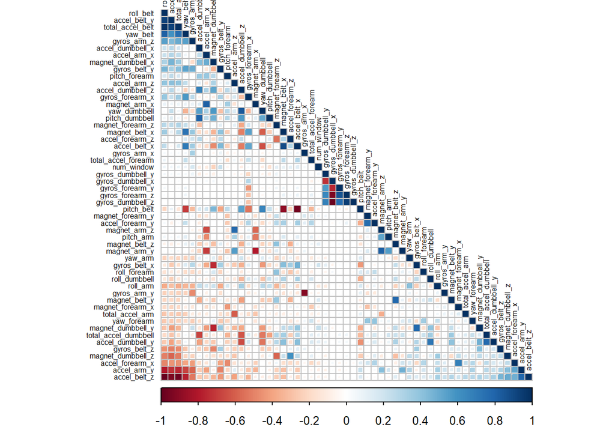

```r
corr_matrix <- cor(training.part[ , -54])
corrplot(corr_matrix, order = "FPC", method = "square", type = "lower",
         tl.cex = 0.5, tl.col = "black")
```

Dark blue color means high correlation and dark red color means negative correlation. Since there are not too much highly correlated variables, the next step is to built prediction models of the data.

*Prediction Models*

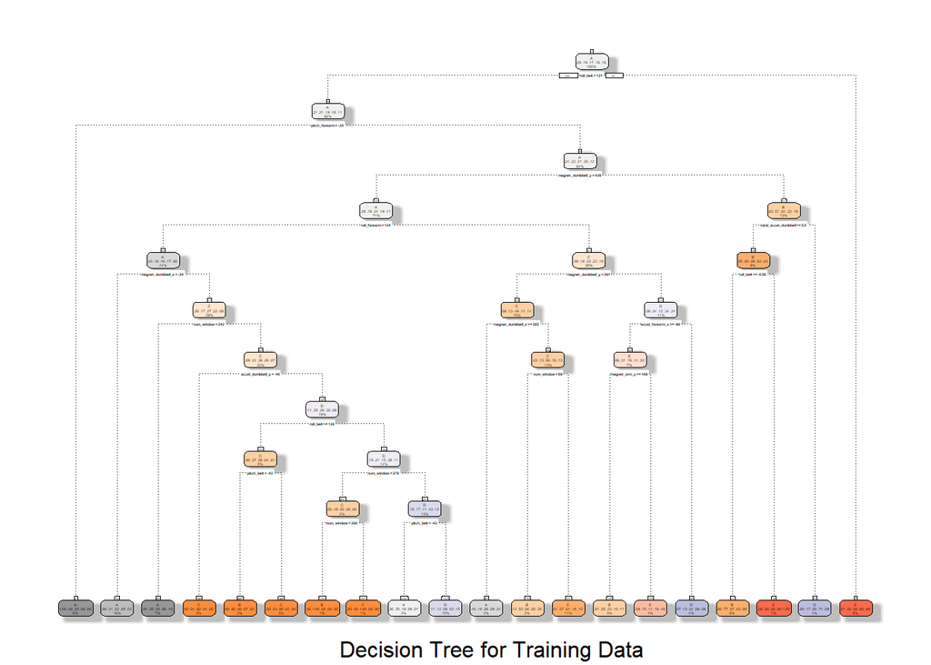

```r
set.seed(100)

decision.tree <- rpart(classe ~ ., data = training.part, method="class")
fancyRpartPlot(decision.tree, sub="Decision Tree for Training Data", palettes=c("Greys", "Oranges"))
```

```r
predict.decision.tree <- predict(decision.tree, newdata = test.part, type="class")
confusion.matrix <- confusionMatrix(table(predict.decision.tree, test.part$classe))
confusion.matrix
```

```
## Confusion Matrix and Statistics
##
##
## predict.decision.tree    A    B    C    D    E
##                     A 1276  206   39  101   79
##                     B   32  559   64   26   90
##                     C    6   50  688  114   50
##                     D   68  107   43  533  106
##                     E   13   27   21   30  576
##
## Overall Statistics
##
##                Accuracy : 0.7406
##                  95% CI : (0.7281, 0.7528)
##     No Information Rate : 0.2845
##     P-Value [Acc > NIR] : < 2.2e-16
##
##                   Kappa : 0.6696
##
##  Mcnemar's Test P-Value : < 2.2e-16
##
## Statistics by Class:
##
##                      Class: A Class: B Class: C Class: D Class: E
## Sensitivity            0.9147   0.5890   0.8047   0.6629   0.6393
## Specificity            0.8789   0.9464   0.9457   0.9210   0.9773
## Pos Pred Value         0.7501   0.7250   0.7577   0.6219   0.8636
## Neg Pred Value         0.9628   0.9056   0.9582   0.9330   0.9233
## Prevalence             0.2845   0.1935   0.1743   0.1639   0.1837
## Detection Rate         0.2602   0.1140   0.1403   0.1087   0.1175
## Detection Prevalence   0.3469   0.1572   0.1852   0.1748   0.1360
## Balanced Accuracy      0.8968   0.7677   0.8752   0.7920   0.8083
```

Plotting the predictive accuracy of the decision tree model.

[figure not shown]

```r
plot(confusion.matrix$table, col = confusion.matrix$byClass, main = paste("Random Forest - Accuracy =",round(confusion.matrix$overall['Accuracy'], 4)))
```

*Applying a Generalized Boosted Model*

```r
control.GBM <- trainControl(method = "repeatedcv", number = 5, repeats = 2)
fit.GBM  <- train(classe ~ ., data = training.part, method = "gbm",
                  trControl = control.GBM, verbose = FALSE)
fit.GBM$finalModel
```

```
## A gradient boosted model with multinomial loss function.
## 150 iterations were performed.
## There were 53 predictors of which 53 had non-zero influence.
```

```r
prediction.GBM <- predict(fit.GBM, newdata = test.part)
confusion.matrix.GBM <- confusionMatrix(table(prediction.GBM, test.part$classe))
confusion.matrix.GBM
```

```
## Confusion Matrix and Statistics
##
##
## prediction.GBM    A    B    C    D    E
##              A 1391   13    0    1    0
##              B    4  928    9    3    3
##              C    0    7  842    5    2
##              D    0    0    4  793    0
##              E    0    1    0    2  896
##
## Overall Statistics
##
##                Accuracy : 0.989
##                  95% CI : (0.9857, 0.9917)
##     No Information Rate : 0.2845
##     P-Value [Acc > NIR] : < 2.2e-16
##
##                   Kappa : 0.9861
##
##  Mcnemar's Test P-Value : NA
##
## Statistics by Class:
##
##                      Class: A Class: B Class: C Class: D Class: E
## Sensitivity            0.9971   0.9779   0.9848   0.9863   0.9945
## Specificity            0.9960   0.9952   0.9965   0.9990   0.9993
## Pos Pred Value         0.9900   0.9799   0.9836   0.9950   0.9967
## Neg Pred Value         0.9989   0.9947   0.9968   0.9973   0.9988
## Prevalence             0.2845   0.1935   0.1743   0.1639   0.1837
## Detection Rate         0.2836   0.1892   0.1717   0.1617   0.1827
## Detection Prevalence   0.2865   0.1931   0.1746   0.1625   0.1833
## Balanced Accuracy      0.9966   0.9865   0.9907   0.9927   0.9969
```

*Applying Random Forest Model*

```r
set.seed(100)
control.randomforest <- trainControl(method = "repeatedcv", number = 5, repeats = 2)
fit.randomforest  <- train(classe ~ ., data = test.part, method = "rf",trControl = control.randomforest, verbose = FALSE)

fit.randomforest$finalModel
```

```
##
## Call:
##  randomForest(x = x, y = y, mtry = param$mtry, verbose = FALSE)
##                Type of random forest: classification
##                      Number of trees: 500
## No. of variables tried at each split: 27
##
##         OOB estimate of  error rate: 1.08%
## Confusion matrix:
##      A   B   C   D   E  class.error
## A 1394   1   0   0   0 0.0007168459
## B    7 929  13   0   0 0.0210748156
## C    0   5 845   5   0 0.0116959064
## D    1   0  17 786   0 0.0223880597
## E    0   1   0   3 897 0.0044395117
```

```r
prediction.randomforest <- predict(fit.randomforest, newdata = test.part)
confusion.matrix.randomforest <- confusionMatrix(table(prediction.randomforest, test.part$classe))
confusion.matrix.randomforest
```

```
## Confusion Matrix and Statistics
##
##
## prediction.randomforest    A    B    C    D    E
##                       A 1395    0    0    0    0
##                       B    0  949    0    0    0
##                       C    0    0  855    0    0
##                       D    0    0    0  804    0
##                       E    0    0    0    0  901
##
## Overall Statistics
##
##                Accuracy : 1
##                  95% CI : (0.9992, 1)
##     No Information Rate : 0.2845
##     P-Value [Acc > NIR] : < 2.2e-16
##
##                   Kappa : 1
##
##  Mcnemar's Test P-Value : NA
##
## Statistics by Class:
##
##                      Class: A Class: B Class: C Class: D Class: E
## Sensitivity            1.0000   1.0000   1.0000   1.0000   1.0000
## Specificity            1.0000   1.0000   1.0000   1.0000   1.0000
## Pos Pred Value         1.0000   1.0000   1.0000   1.0000   1.0000
## Neg Pred Value         1.0000   1.0000   1.0000   1.0000   1.0000
## Prevalence             0.2845   0.1935   0.1743   0.1639   0.1837
## Detection Rate         0.2845   0.1935   0.1743   0.1639   0.1837
## Detection Prevalence   0.2845   0.1935   0.1743   0.1639   0.1837
## Balanced Accuracy      1.0000   1.0000   1.0000   1.0000   1.0000
```

```r
predict.data.test <- predict(fit.randomforest, newdata = data.test)
predict.data.test
```

```
##  [1] B A B A A E D B A A B C B A E E A B B B
## Levels: A B C D E
```